# Course Project Machine Learning

pguillemi

13/9/2022

## Course Project

One thing that people regularly do is quantify how much of a particular activity they do, but they rarely quantify how well they do it. In this project, your goal will be to use data from accelerometers on the belt, forearm, arm, and dumbell of 6 participants. The goal of your project is to predict the manner in which they did the exercise. This is the “classe” variable in the training set. You may use any of the other variables to predict with.

## Introduction

Using devices such as Jawbone Up, Nike FuelBand, and Fitbit it is now possible to collect a large amount of data about personal activity relatively inexpensively. These type of devices are part of the quantified self movement – a group of enthusiasts who take measurements about themselves regularly to improve their health, to find patterns in their behavior, or because they are tech geeks. One thing that people regularly do is quantify how much of a particular activity they do, but they rarely quantify how well they do it. In this project, your goal will be to use data from accelerometers on the belt, forearm, arm, and dumbell of 6 participants. They were asked to perform barbell lifts correctly and incorrectly in 5 different ways. The data for this project come from this source: http://groupware.les.inf.puc-rio.br/har

## Model building

Data gathering and preprocessing is shown here. Dataset consists of 19622 observations with 160 variables. There were many variables that were mostly populated with NA values. These were discarded. Also, there were contextual variables such as the name of the participants or data collection timestamps which didn’t seem relevant at all for the purpose of fitting models were also discarded for training.

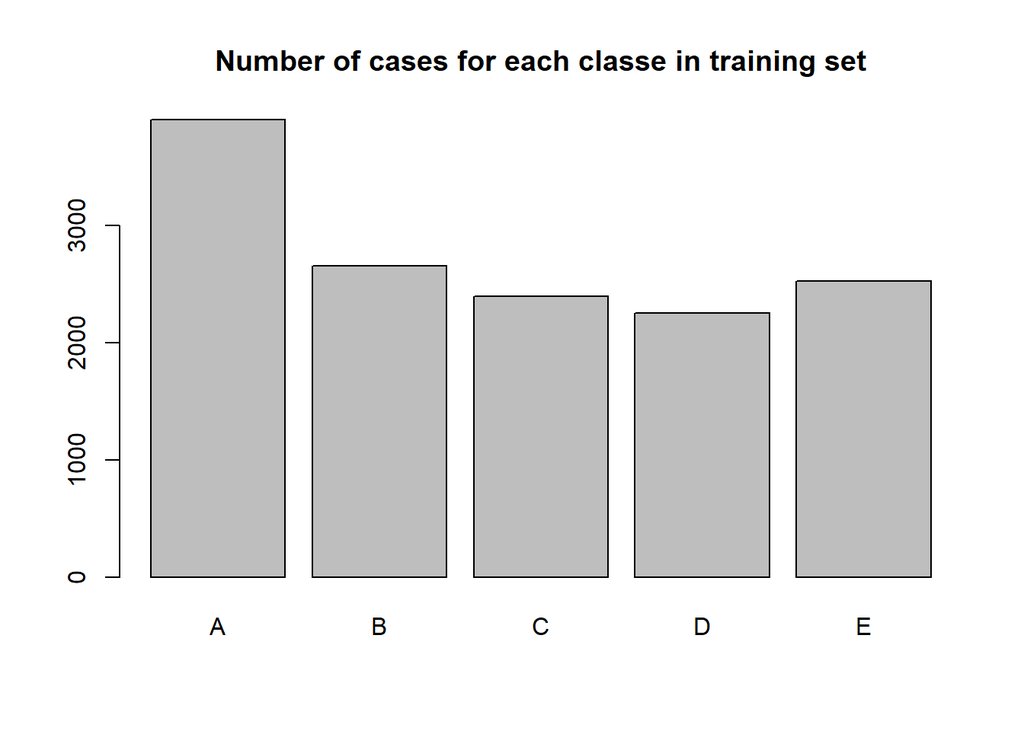

```r
#load files, download link embedded in code
if(file.exists("./pml-training.csv")){base_training <- read_csv("./pml-training.csv", guess_max = 19000,show_col_types = FALSE)} else {
  download.file(url = "https://d396qusza40orc.cloudfront.net/predmachlearn/pml-training.csv",
                method = "curl",
                destfile = "./pml-training.csv" )
base_training <- read_csv("./pml-training.csv", guess_max = 19000,show_col_types = FALSE)
}
if(file.exists("./pml-testing.csv")){testing <- read_csv("./pml-testing.csv", guess_max = 19000,show_col_types = FALSE)
  } else {
  download.file(url = "https://d396qusza40orc.cloudfront.net/predmachlearn/pml-testing.csv",
                method = "curl",
                destfile = "./pml-testing.csv" )
testing <- read_csv("./pml-testing.csv", guess_max = 19000,show_col_types = FALSE)
}
#check base
base_col <- colnames(base_training)
base_summary <- tibble(
  var = base_col,
  obs_w_data = "",
  obs_na = "",
  distinct_val_in_obs = "",
  class = sapply(base_training,class)
)

for(i in 1:nrow(base_summary)){
  resu <- base_training %>% group_by(base_training[,i]) %>%
    summarise(num = n())

  resu_na <- resu %>% filter(is.na(resu[,1]))
  resu_not_na <- resu %>% filter(!is.na(resu[,1]))

  base_summary$obs_w_data[i] <- sum(resu_not_na$num)
  base_summary$obs_na[i] <- sum(resu_na$num)
  base_summary$distinct_val_in_obs[i] <- nrow(resu_not_na)
}

#remove cols with NA and convert classe to factor
complete <- base_summary %>% filter(obs_na == 0)
complete_var <- as.vector(complete$var)
base_training <- as.data.frame(base_training[,complete_var])
base_training$classe <- as.factor(base_training$classe)

#after examining "base_summary" object, first seven columns have no relevant data for prediction
base_training <- base_training %>%
  select(8:ncol(base_training))

#set training and validation sets, put validation set aside
set.seed(12345)
in_training <- createDataPartition(base_training$classe, p = 0.7, list = FALSE)
training <- base_training[in_training,]

validation <- base_training[-in_training,]

plot(training$classe, main = "Number of cases for each classe in training set")
```

### Cross validation and model choices

I decided to start with a 3 k-fold cross validation, so as to make use of the technique, but also reduce processing times in first approaches. This is a classification situation, so the following models were chosen to train and evaluate predictions: decision trees (“rpart”), random forests (“rf”), gradient boosting algorithms (“gbm”) and linear discriminat analysis (“lda”) Then applied predictions on validation sample, and chose the best method to use on the test samples.

```r
#Establish 3 k-fold cross validation for training, it is very conservative. If results are not good enough, 10 k-fold validation will be used
train_control<- trainControl(method="cv", number=3)

#model tree, load if already generated for saving time when knitting
if(file.exists("./model_tree.RData")){
  model_tree <- readRDS("./model_tree.RData")} else {
model_tree <- train(classe~. , data = training, method = "rpart", trControl=train_control, tuneLength = 5)
saveRDS(model_tree, file = "model_tree.RData")
}

#model rf
if(file.exists("./model_rf.RData")){
  model_rf <- readRDS("./model_rf.RData")} else {
model_rf <- train(classe~. , data = training, method = "rf", trControl=train_control)
saveRDS(model_rf, file = "model_rf.RData")
}

#model lda
if(file.exists("./model_lda.RData")){
  model_lda <- readRDS("./model_lda.RData")} else {
model_lda <- train(classe~. , data = training, method = "lda", trControl=train_control)
saveRDS(model_lda, file = "model_lda.RData")
  }

#model gbm
if(file.exists("./model_gbm.RData")){
  model_gbm <- readRDS("./model_gbm.RData")} else {
model_gbm <- train(classe~. , data = training, method = "gbm", trControl=train_control)
saveRDS(model_gbm, file = "model_gbm.RData")
}

#test on validation dataset
matrix_tree <- confusionMatrix(validation$classe, predict(model_tree,validation))
matrix_rf <- confusionMatrix(validation$classe,predict(model_rf,validation))
matrix_lda <- confusionMatrix(validation$classe,predict(model_lda,validation))
matrix_gbm <- confusionMatrix(validation$classe,predict(model_gbm,validation))

summary <- data.frame(
  tree = matrix_tree$overall[1],
  rf = matrix_rf$overall[1],
  lda = matrix_lda$overall[1],
  gbm = matrix_gbm$overall[1]
)

kable(summary)
```

|  | tree | rf | lda | gbm |
| --- | --- | --- | --- | --- |
| Accuracy | 0.5413764 | 0.9945624 | 0.7070518 | 0.9617672 |

## Final results and chosen model

When checking on validation dataset, the accuracy is, from highest lo lowest rf, gbm, lda and decision trees. Random forest accuracy is above 99.4%, so no further model tuning seems necessary. However it is to note that the expected out of sample error is expected to be larger on the test set that on the training or validation sets. That being said, the attained accuracy in validation set weem fairly good enough to proceed to predict valuest on testing dataset. Finally, predicted values on testing dataset were obtained as follows (actual results not shown so as to preserve them)

```r
#predict on test
#apply same overall corrections first, results object contents are not shown
complete_var_test <- complete %>%
  filter(var != "classe")
complete_var_test <- complete_var_test$var

testing <- testing[,complete_var_test]

results <- predict(model_rf, testing)
```